# Homework_5

Burakhan Sel

6 Ocak 2019

## Musk Dataset

### Data Preparation

I started with data preparation operations such as splitting data into test and train data sets, scaling the numeric features, giving columns proper names and etc. All the operations that are done in this part are explained with the comments in the code.

```r
# set directory
setwd("c:/Users/Burakhan/Desktop/Dersler/IE 582/HW5")

#read data
musk1<-as.data.table(read.csv("Musk1.csv",header = FALSE))

#Give names to columns
colnames(musk1)[1]<-"Bag class"
colnames(musk1)[2]<-"Bag Id"

#scale and copy data
musk_features<-musk1[,3:ncol(musk1)]
musk_features<-(scale(musk_features))
musk<-musk1
musk1[,3:ncol(musk)]<-as.data.table(scale(musk1[,3:ncol(musk1)]))
musk_features1<-musk_features

#seperate train and test data
set.seed(1)
smp_size <- floor(0.75 * nrow(musk1))# 1/3 of the data goes to test data
train_ind <- sample(seq_len(nrow(musk1)), size = smp_size)
musk<-musk1[train_ind, ]#musk is train data
test<-musk1[-train_ind, ]#test data
musk_features<-musk_features1[train_ind, ]#train data without bag class and bag ID
test_musk_feature<-musk_features1[-train_ind, ]#test data without bag class and bag ID
```

## Clustering and Classification

As a methodology, I followed this path in a for loop that tries different parameters:

**1-**Calculate distance matrices

**2-**Cluster instances with the distance matrix

**3-**Find each cluster’s centroid

**4-**Calculate distance from each instance to each centroid

**5-**Calculate average distances of the instances of each bag. (Ended up with 88*21 bag level representation data. The reason of 88 rows instead of 92 is some of the bags are in the test data)

**6-**Perform cross-validation to lasso logistic regression with the help of the cv.glmnet function and AUC performance measure

**7-**Register each parameter, method and related AUC values.

**Parameters**

**1-Distance measure:** As a distance measure I used Euclidean and Pearson measures. While Euclidean is depending on the squared distances between variables, Pearson is depending on the correlation between variables

**2-Number of cluster:**I tried 5,10,15,and 20

**3-Linkage:**This parameter is for hierarchical clustering. The method that is used to find each clusters similarity. Complete, average, single, and centroid linkages are tried.

```r
#parameters
distance<-c("euclidean","pearson")
number_of_cluster<-c(5,10,15,20)
linkage<-c("complete","average","single","centroid")
```

```r
set.seed(1)
result<-data.table()
for(r in 1:length(distance)){
musk_dist<-get_dist(musk_features,method = distance[r],stand = TRUE)

    #Kmeans
    for(l in 1:length(number_of_cluster)){
          #step 1:Cluster instances (K-medoids)
          kmedoids <- pam(musk_dist,k=number_of_cluster[l],diss = TRUE)

          #step 2:Finding he distance of instances to each cluster centroid
          centroids<-as.data.table(musk_features[kmedoids$medoids,])
          musk_and_centroid<-rbind(musk_features,centroids)
          musk_and_centroid_dist<-as.matrix(get_dist(musk_and_centroid,method = distance[r],stand = TRUE))
          centroid_dist<-as.data.table(musk_and_centroid_dist[1:nrow(musk),(ncol(musk_and_centroid_dist)-number_of_cluster[l]+1):ncol(musk_and_centroid_dist)])
          musk2<-cbind(musk,centroid_dist)
          musk_bag_level<-as.data.table(aggregate(musk2[,(ncol(musk)-number_of_cluster[l]+1):ncol(musk)], list(musk$`Bag Id`), mean))

          #step 3:Represent the bag as the average of its instance distances to the cluster centroids
          musk_bag_class<-as.data.table(aggregate(musk2$`Bag class`, list(musk$`Bag Id`), mean))
          musk_final<-merge(musk_bag_class,musk_bag_level,by="Group.1")
          musk_final<-musk_final[,Group.1:=NULL]
          colnames(musk_final)[1]<-"Class"
          lambda<-cv.glmnet(x=as.matrix(musk_final[,2:ncol(musk_final)]),y=musk_final$Class,nfolds =6,type.measure="auc", alpha = 1,standardize = TRUE, family="binomial")
          result=rbind(result, data.table(Clustering_Method="Kmeans",Best_Lambda=lambda$lambda.min, AUC=max(lambda$cvm),Distance=distance[r],number_of_cluster=number_of_cluster[l],linkage=NA))
        }

    #Hierarchical Clustering
    for(l in 1:length(number_of_cluster)){
        for (m in 1:length(linkage)) {
          #step 1:Cluster instances (Hierarchical Clustering)
          hc =hcluster(musk_features,link=linkage[m],method = distance[r])
          hc_cluster<-cutree (hc , number_of_cluster[l])

          #step 2:Finding he distance of instances to each cluster centroid
          musk_and_cluster<-cbind(musk,hc_cluster)
          centroids<-data.table()
                    for(z in 1:number_of_cluster[l]){
                    temp<-subset(musk_and_cluster,hc_cluster==z)
                    temp<-temp[,3:168]
                    if (nrow(temp)>=2){
                    cent<-pam(temp,k = 1)
                    centroids<-rbind(centroids,cent$medoids)
                    } else {
                    centroids<-rbind(centroids,temp)
                    }}

          musk_and_centroid<-as.data.table(rbind(musk_features,centroids))
          musk_and_centroid_dist<-as.matrix(get_dist(musk_and_centroid,method = distance[r],stand = TRUE))
          centroid_dist<-as.data.table(musk_and_centroid_dist[1:nrow(musk),(ncol(musk_and_centroid_dist)-number_of_cluster[l]+1):ncol(musk_and_centroid_dist)])
          musk2<-cbind(musk,centroid_dist)
          musk_bag_level<-as.data.table(aggregate(musk2[,(ncol(musk)-number_of_cluster[l]+1):ncol(musk)], list(musk$`Bag Id`), mean))

          #step 3:Represent the bag as the average of its instance distances to the cluster centroids
          musk_bag_class<-as.data.table(aggregate(musk2$`Bag class`, list(musk$`Bag Id`), mean))
          musk_final<-merge(musk_bag_class,musk_bag_level,by="Group.1")
          musk_final<-musk_final[,Group.1:=NULL]
          colnames(musk_final)[1]<-"Class"
          lambda<-cv.glmnet(x=as.matrix(musk_final[,2:ncol(musk_final)]),y=musk_final$Class,nfolds =6,type.measure="auc", alpha = 1,standardize = TRUE, family="binomial")
          result=rbind(result, data.table(Clustering_Method="HC",Best_Lambda=lambda$lambda.min, AUC=max(lambda$cvm),Distance=distance[r],number_of_cluster=number_of_cluster[l],linkage=linkage[m]))
        }
      }

}

print(result[order(-AUC),])
```

```
##     Clustering_Method  Best_Lambda       AUC  Distance number_of_cluster
##  1:                HC 0.0437859187 0.8434253   pearson                10
##  2:            Kmeans 0.0018518128 0.8317370   pearson                20
##  3:                HC 0.0024479876 0.8316062 euclidean                20
##  4:                HC 0.0274988330 0.8315837 euclidean                10
##  5:                HC 0.0765171363 0.8301509   pearson                10
##  6:                HC 0.0056551689 0.8290449 euclidean                20
##  7:                HC 0.0029486097 0.8226572   pearson                20
##  8:                HC 0.0527402940 0.8220394 euclidean                15
##  9:                HC 0.0363518389 0.8210859 euclidean                20
## 10:                HC 0.0068116709 0.8155619 euclidean                10
## 11:                HC 0.0635258708 0.8113681 euclidean                15
## 12:                HC 0.0074758004 0.8012081   pearson                20
## 13:            Kmeans 0.0437859187 0.7993191 euclidean                10
## 14:                HC 0.0697195648 0.7985931   pearson                15
```

[output cut: 69 more lines]

The biggest AUC values are observed with hierarchical clustering method for both Pearson and Euclidean distance measures. We know that the biggest differences in clustering are not due to different models but due to different distance measures and parameters. In this table, although the difference between Pearson and the Euclidean method is not observed well, the similarity of HC and K-medoids in terms of AUC is observed.

## Test

### Pearson Distance

The best clustering method for Pearson distance measure is Hierarchical Clustering with 10 clusters and complete linkage. Also, I will use 0.0437859187 as a lambda value in the logistic regression resulted from cross-validation of the lasso logistic regression.

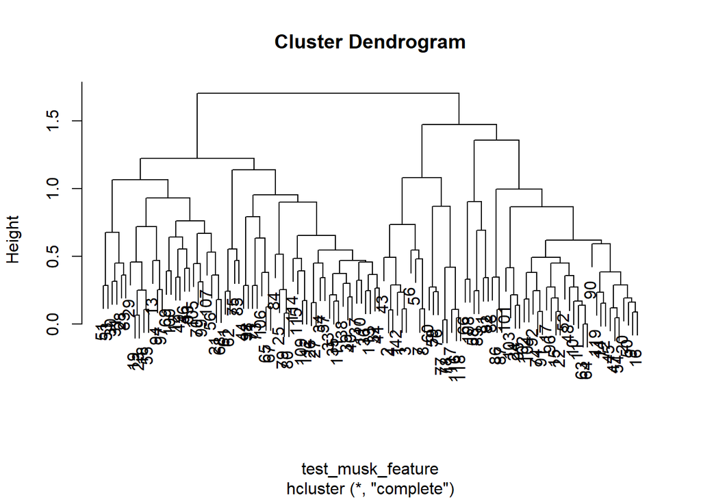

```r
#Model construction
#Best performing clustering method for pearson is Hierarchical Clustering
r<-2 #distance measure is pearson
l<-2 #number of cluster is 10
m<-1 #linkage method is comlete
best_lambda<-0.0437859187


#step 1:Cluster instances (Hierarchical Clustering)
hc =hcluster(musk_features,link=linkage[m],method = distance[r])
hc_cluster<-cutree (hc , number_of_cluster[l])

#step 2:Finding he distance of instances to each cluster centroid
musk_and_cluster<-cbind(musk,hc_cluster)
centroids<-data.table()
for(z in 1:number_of_cluster[l]){
  temp<-subset(musk_and_cluster,hc_cluster==z)
  temp<-temp[,3:168]
  if (nrow(temp)>=2){
    cent<-pam(temp,k = 1)
    centroids<-rbind(centroids,cent$medoids)
  } else {
    centroids<-rbind(centroids,temp)
  }}

musk_and_centroid<-as.data.table(rbind(musk_features,centroids))
musk_and_centroid_dist<-as.matrix(get_dist(musk_and_centroid,method = distance[r],stand = TRUE))
centroid_dist<-as.data.table(musk_and_centroid_dist[1:nrow(musk),(ncol(musk_and_centroid_dist)-number_of_cluster[l]+1):ncol(musk_and_centroid_dist)])
musk2<-cbind(musk,centroid_dist)
musk_bag_level<-as.data.table(aggregate(musk2[,(ncol(musk)-number_of_cluster[l]+1):ncol(musk)], list(musk$`Bag Id`), mean))

#step 3:Represent the bag as the average of its instance distances to the cluster centroids
musk_bag_class<-as.data.table(aggregate(musk2$`Bag class`, list(musk$`Bag Id`), mean))
musk_final<-merge(musk_bag_class,musk_bag_level,by="Group.1")
musk_final<-musk_final[,Group.1:=NULL]
colnames(musk_final)[1]<-"Class"
best_glmnet<-glmnet(x=as.matrix(musk_final[,2:ncol(musk_final)]),y=musk_final$Class, alpha = 1,standardize = TRUE, family="binomial",lambda = best_lambda)



#test data preparation
#step 1:Cluster instances (Hierarchical Clustering)
hc =hcluster(test_musk_feature,link=linkage[m],method = distance[r])
hc_cluster<-cutree (hc , number_of_cluster[l])
plot(hc)
```

```r
#step 2:Finding he distance of instances to each cluster centroid
musk_and_cluster<-cbind(test,hc_cluster)
centroids<-data.table()
for(z in 1:number_of_cluster[l]){
  temp<-subset(musk_and_cluster,hc_cluster==z)
  temp<-temp[,3:168]
  if (nrow(temp)>=2){
    cent<-pam(temp,k = 1)
    centroids<-rbind(centroids,cent$medoids)
  } else {
    centroids<-rbind(centroids,temp)
  }}

musk_and_centroid<-as.data.table(rbind(test_musk_feature,centroids))
musk_and_centroid_dist<-as.matrix(get_dist(musk_and_centroid,method = distance[r],stand = TRUE))
centroid_dist<-as.data.table(musk_and_centroid_dist[1:nrow(test),(ncol(musk_and_centroid_dist)-number_of_cluster[l]+1):ncol(musk_and_centroid_dist)])
musk2<-cbind(test,centroid_dist)
musk_bag_level<-as.data.table(aggregate(musk2[,(ncol(test)-number_of_cluster[l]+1):ncol(test)], list(test$`Bag Id`), mean))

#step 3:Represent the bag as the average of its instance distances to the cluster centroids
musk_bag_class<-as.data.table(aggregate(musk2$`Bag class`, list(test$`Bag Id`), mean))
musk_final<-merge(musk_bag_class,musk_bag_level,by="Group.1")
musk_final<-musk_final[,Group.1:=NULL]
colnames(musk_final)[1]<-"Class"

lasso.prob <- as.numeric(predict(best_glmnet,type="class", as.matrix(musk_final[,2:ncol(musk_final)])))
pred <- prediction(lasso.prob, musk_final$Class)

# calculate probabilities for TPR/FPR for predictions
perf <- performance(pred,"tpr","fpr")
performance(pred,"auc") # shows calculated AUC for model
```

```
## An object of class "performance"
## Slot "x.name":
## [1] "None"
##
## Slot "y.name":
## [1] "Area under the ROC curve"
##
## Slot "alpha.name":
## [1] "none"
##
## Slot "x.values":
## list()
##
## Slot "y.values":
## [[1]]
## [1] 0.7487179
##
##
## Slot "alpha.values":
## list()
```

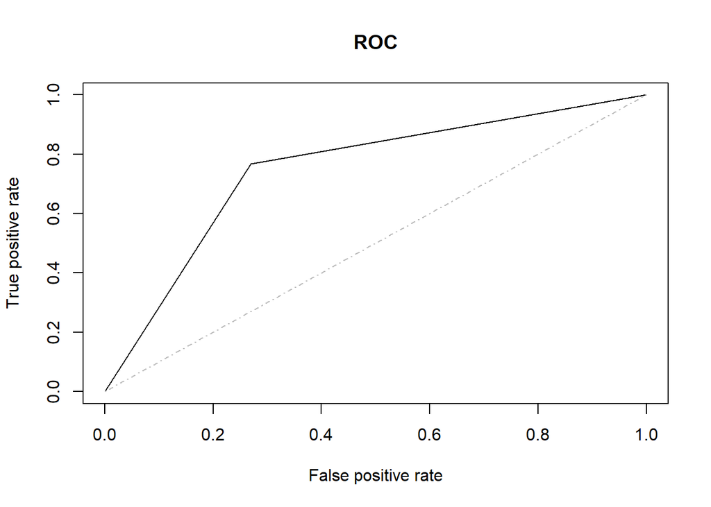

```r
plot(perf,colorize=FALSE, col="black",main="ROC") # plot ROC curve
lines(c(0,1),c(0,1),col = "gray", lty = 4 )
```

The AUC value is 0.7487179 which is less than the AUC value in the cross-validation.

### Euclidean Distance

The best clustering method for Euclidean distance is hierarchical clustering with 20 clusters and single linkage. Also, 0.0024479876 will be used as a lambda for lasso logistic regression.

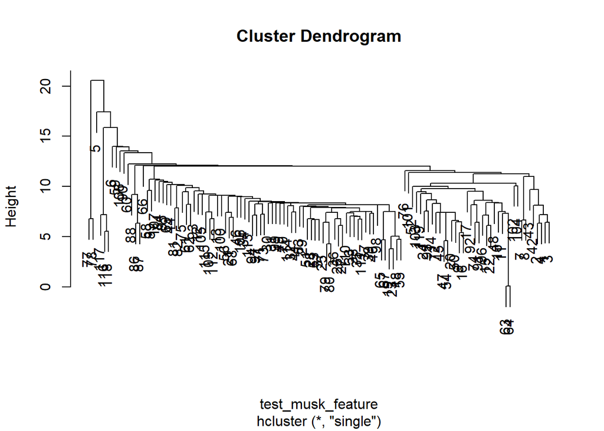

```r
#Model construction
#Best performing clustering method for euclidean is Hierarchical Clustering
r<-1 #distance measure is euclidean
l<-4 #number of cluster is 20
m<-3 #linkage method is single
best_lambda<-0.0024479876


#step 1:Cluster instances (Hierarchical Clustering)
hc =hcluster(musk_features,link=linkage[m],method = distance[r])
hc_cluster<-cutree (hc , number_of_cluster[l])

#step 2:Finding he distance of instances to each cluster centroid
musk_and_cluster<-cbind(musk,hc_cluster)
centroids<-data.table()
for(z in 1:number_of_cluster[l]){
  temp<-subset(musk_and_cluster,hc_cluster==z)
  temp<-temp[,3:168]
  if (nrow(temp)>=2){
    cent<-pam(temp,k = 1)
    centroids<-rbind(centroids,cent$medoids)
  } else {
    centroids<-rbind(centroids,temp)
  }}

musk_and_centroid<-as.data.table(rbind(musk_features,centroids))
musk_and_centroid_dist<-as.matrix(get_dist(musk_and_centroid,method = distance[r],stand = TRUE))
centroid_dist<-as.data.table(musk_and_centroid_dist[1:nrow(musk),(ncol(musk_and_centroid_dist)-number_of_cluster[l]+1):ncol(musk_and_centroid_dist)])
musk2<-cbind(musk,centroid_dist)
musk_bag_level<-as.data.table(aggregate(musk2[,(ncol(musk)-number_of_cluster[l]+1):ncol(musk)], list(musk$`Bag Id`), mean))

#step 3:Represent the bag as the average of its instance distances to the cluster centroids
musk_bag_class<-as.data.table(aggregate(musk2$`Bag class`, list(musk$`Bag Id`), mean))
musk_final<-merge(musk_bag_class,musk_bag_level,by="Group.1")
musk_final<-musk_final[,Group.1:=NULL]
colnames(musk_final)[1]<-"Class"
best_glmnet<-glmnet(x=as.matrix(musk_final[,2:ncol(musk_final)]),y=musk_final$Class, alpha = 1,standardize = TRUE, family="binomial",lambda = best_lambda)



#test data preparation
#step 1:Cluster instances (Hierarchical Clustering)
hc =hcluster(test_musk_feature,link=linkage[m],method = distance[r])
hc_cluster<-cutree (hc , number_of_cluster[l])
plot(hc)
```

```r
#step 2:Finding he distance of instances to each cluster centroid
musk_and_cluster<-cbind(test,hc_cluster)
centroids<-data.table()
for(z in 1:number_of_cluster[l]){
  temp<-subset(musk_and_cluster,hc_cluster==z)
  temp<-temp[,3:168]
  if (nrow(temp)>=2){
    cent<-pam(temp,k = 1)
    centroids<-rbind(centroids,cent$medoids)
  } else {
    centroids<-rbind(centroids,temp)
  }}

musk_and_centroid<-as.data.table(rbind(test_musk_feature,centroids))
musk_and_centroid_dist<-as.matrix(get_dist(musk_and_centroid,method = distance[r],stand = TRUE))
centroid_dist<-as.data.table(musk_and_centroid_dist[1:nrow(test),(ncol(musk_and_centroid_dist)-number_of_cluster[l]+1):ncol(musk_and_centroid_dist)])
musk2<-cbind(test,centroid_dist)
musk_bag_level<-as.data.table(aggregate(musk2[,(ncol(test)-number_of_cluster[l]+1):ncol(test)], list(test$`Bag Id`), mean))

#step 3:Represent the bag as the average of its instance distances to the cluster centroids
musk_bag_class<-as.data.table(aggregate(musk2$`Bag class`, list(test$`Bag Id`), mean))
musk_final<-merge(musk_bag_class,musk_bag_level,by="Group.1")
musk_final<-musk_final[,Group.1:=NULL]
colnames(musk_final)[1]<-"Class"

lasso.prob <- as.numeric(predict(best_glmnet,type="class", as.matrix(musk_final[,2:ncol(musk_final)])))
pred <- prediction(lasso.prob, musk_final$Class)

# calculate probabilities for TPR/FPR for predictions
perf <- performance(pred,"tpr","fpr")
performance(pred,"auc") # shows calculated AUC for model
```

```
## An object of class "performance"
## Slot "x.name":
## [1] "None"
##
## Slot "y.name":
## [1] "Area under the ROC curve"
##
## Slot "alpha.name":
## [1] "none"
##
## Slot "x.values":
## list()
##
## Slot "y.values":
## [[1]]
## [1] 0.7346154
##
##
## Slot "alpha.values":
## list()
```

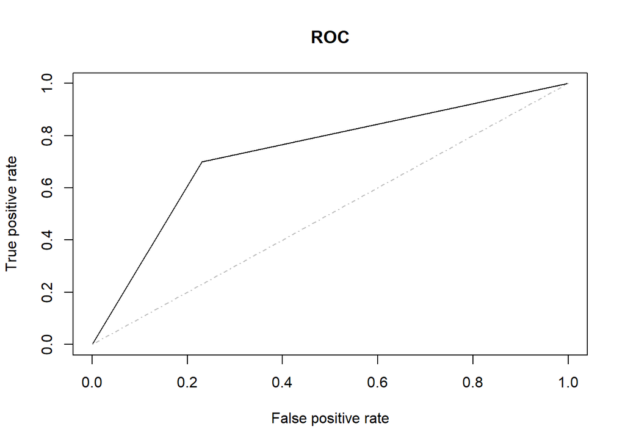

```r
plot(perf,colorize=FALSE, col="black", main="ROC") # plot ROC curve
lines(c(0,1),c(0,1),col = "gray", lty = 4 )
```

The AUC value of the test of Euclidean distance is 0.7346154 which is smaller than the values in the cross-validation and the test of the Pearson distance.

## Conclusion

As expected, almost similar performances of clustering methods are observed in terms of the purpose of this study. However, I was expecting significant differences in the AUC values for the different distance measures but they also observed similarly in the analyses.